# Deep learning DNA sequence

## A hybrid model of CNN & RNN in predicting drug resistance

**Email: ningyao@hsph.harvard.edu Github: https://github.com/estelleyao0530 Linkedin: https://www.linkedin.com/in/estelle-yao-174866160/**

### Notebook Contents

- Part A: Data processing
- Part B: Model construction and training
- Part C: Model evaluation
- Part D: Feature visualization
- Part E: Conclusion and challenges

### Load packages

```python
import pandas as pd
from sklearn.preprocessing import OneHotEncoder
import csv
import numpy as np
from joblib import Parallel, delayed
import multiprocessing
from sklearn.model_selection import train_test_split
from sklearn.model_selection import RandomizedSearchCV
import tensorflow as tf
from tensorflow.keras.models import Sequential
from tensorflow.keras.layers import Dense, Dropout, Activation, Flatten, Conv2D,Conv1D, MaxPooling2D, Conv2D,Conv1D, MaxPooling2D,MaxPooling1D, LSTM, Bidirectional
from tensorflow.keras.wrappers.scikit_learn import KerasClassifier
from sklearn.model_selection import GridSearchCV
import matplotlib.pyplot as plt
```

### Dataset information

From "dataset.npy" loaded DNA sequences and drug resistance status for each of the 100,000 samples (genes). For the purpose of this project, I downsampled to 1,000 samples followed by a 80-20% train-test split.

```python
###Read in data
data = np.load("dataset.npy", allow_pickle=True).item()
xs = data["genes"] # [n_sample, arbitrary length string object]
ys = data["resistant"] # [n_sample] (bool)

codon=pd.read_csv("codons_aa.txt", sep=" ", header=None)
codon.columns=['key','value']

###change data type key from object to string
str_codon=[]
for i in codon['key']:
    str_codon.append(str(i))
codon['code']=str_codon
codon.code=codon.code.astype("string")
```

```python
###Downsample stratified by y response
unique, counts = np.unique(ys, return_counts=True)

T=np.where(ys==True)
F=np.where(ys==False)

np.random.seed(189)
T_choice=np.random.choice(T[0], round(len(xs)*counts[0]/sum(counts)*0.01))
T_choice.sort()
F_choice=np.random.choice(F[0], round(len(xs)*counts[1]/sum(counts)*0.01))
F_choice.sort()
allchoice=np.concatenate((T_choice,F_choice))

down_x=xs[allchoice]
down_x.shape
down_y=ys[allchoice]
down_y.shape
```

```
(1000,)
```

### Part A: Data Processing

DNA sequences are analogous to parsing text data for they are both sequential in nature. With a 3mer-based reading frame, 3 DNA neucleotides can be binned to correspond mRNA code which serves as the basis for amino acids, coding for functional proteins. For each DNA sample, there are three possible open reading frames. In order to capture all reading frames, I transformed DNA sequences into a series of "words" by binning each of the three DNA sequences as mRNA by going through each seqeunce. To increase continuity of DNA sequence patterns, I then stacked mRNA code in sequence on top of each other. To keep each sample the same length, I used the shortest length out of all genes as a limit to trim the end of each genetic sequence.

To translate each mRNA code into numerical vector, I applied one-hot-encoding to the 64 possible 3mers. Thus, a single gene sample's mRNA code corresponds to a 64 X 891 2D numeric numpy array. After concactnating two nearest sequential mRNA codes, we will have a 128 X 891 2D numeric matrix per sample. Trnasforming each of the 1000 gene samples randomly selected from the previous section stratified by resistance type, the final numpy array results in a 3D matrix of shape 1000 X 128 X 891.

Advantages of this method include:

1. Thoroughly accounting for each possible transcription outcomes (mRNAs)
2. Increasing the continuity of pattern in each genetic sample

(reference: "DNA Sequence Classification by Convolutional Neural Network" Nguyen et al. https://www.scirp.org/pdf/JBiSE_2016042713533805.pdf)

*Graphical abstract of data processing:*

[figure not shown]

```python
##From all 64 possible combinations of codons, do one hot encoding

enc = OneHotEncoder(handle_unknown='ignore')
enc.fit(codon[['key']])
encode=enc.transform(codon[['key']]).toarray()
```

```python
##Define a function to process all samples by parallel processing

def process(index):

    ##Sample from down_sized pool
    s=down_x[index]

    ##Trim length to match the shortest length of the entire data
    if len(s)> len(min(xs, key=len)):
        s=s[0:len(min(xs, key=len) )]

    ##Find all possible open reading frame
    group=[s[i:i+3] for i in range(0, len(s))]

    ##Concactnate with the next closest word (mRNA)
    long=[]
    for i in range(len(group)-1):
        if len(group[i])==3 & len(group[i+1])==3:
            g1=group[i]
            g2=group[i+1]
            bind=np.concatenate((encode[codon.index[codon['code']==g1][0]],
                                 encode[codon.index[codon['code']==g2][0]]))
            long.append(bind)
    longstack=np.column_stack(long)
    return (longstack)

inputs = range(len(down_x))

###Parallel processing of the selected samples
num_cores = multiprocessing.cpu_count()
results = Parallel(n_jobs=num_cores-2)(delayed(process)(i) for i in inputs)

###Stack all samples to form a 3D array
nn_input=np.stack(results)

###Initialize data object for model fitting
data_new=nn_input
train_y=down_y
```

### Part B: Model construction and training

According to a recent paper "NCNet: Deep Learning Network Models for Predicting Function of Non-coding DNA" by Zhang et al., a hybrid framework integrating a Convolutional Neural Network (CNN) and bi-directional LSTM Recurrent Neural Network (RNN) are accurate in predicting the noncoding function from a sequence. This hybrid model takes advantage of the DNA sequence parsed as text data processed above (3D numpy array) and used one 1D convolutional layer followed by a max pooling to comprehensively learn features of the dataset. Then using the bi-directional LSTM RNN further trains the model to recognize the temporal nature of the DNA reads. The combinations of such model are plausible to reach optimal performance in predicting DNA function, which is fitting for the purpose of this project.

The deployment of a bi-directional LSTM RNN fits a biological context. Becuase one DNA strand has 6 open reading frames, three on the forward strand and three on the backward strand, the bi-directional structure allowed the model to learn the input sequence in a forward timestemp and backward timestemp. Thus, I believe that a bidirectional structure can outperform a single direction LSTM for DNA sequences.

A graphical presentation of the model structure (Zhang et al.):

[figure not shown]

The convolutionary layer with ReLU activation was followed by maxpooling and a drop out to avoid overfitting. Maxpooling was followed by a bi-directional RNN LSTM layer with another drop out layer. Both forward and backward LSTM utilized Relu activation. Then, a flatten layer and two dense layer with a final activation function was set to sigmoid for the binary outcome. ADAM optimizer was used and the objective function was binary crossentropy.

Three key features were chosen to tune with 5-fold cross validation random-grid search to speed up computation. First, I tuned the the number of filters in the 1D CNN layer. I chose to determine kernel_size as 3 to mimic the translational process that reads 3 amino acids at once. Becuase the CNN and RNN are sensitive to the number of epochs and batch size trained, I also added these two parameters into the parameter grid.

```python
##https://machinelearningmastery.com/grid-search-hyperparameters-deep-learning-models-python-keras/
##Model creation to CV with KerasClassifier

def create_model(num_filters=32):
    model=Sequential()

    ###1D CNN
    model.add(Conv1D(filters=num_filters, ###tune parameter
                     kernel_size=3, ###open reading frame
                     activation="relu",
                     input_shape=data_new.shape[1:] ) )
    model.add(MaxPooling1D(pool_size=3,strides=3))
    model.add(Dropout(0.2))

    ###Bidirectional RNN LSTM
    forward_layer = LSTM(32,
                         activation='relu',
                         return_sequences=True)
    backward_layer = LSTM(32,
                          activation='relu',
                          return_sequences=True,
                          go_backwards=True)
    model.add(Bidirectional(forward_layer,
                            backward_layer=backward_layer))
    model.add(Dropout(0.5))

    ###Flatten
    model.add(Flatten())

    ###Dense
    model.add(Dense(64))
    model.add(Activation('relu'))

    model.add(Dense(1))
    model.add(Activation('sigmoid'))

    ##Model compilation
    model.compile(loss="binary_crossentropy",
                  optimizer="adam",
                  metrics=['accuracy'])
    return model
```

```python
###Train-test split (80-20%)
Xtrain, X_test, ytrain, y_test = train_test_split(
    data_new, train_y,
    test_size=0.2,
    random_state=42,
    stratify= train_y)
```

```python
# define the grid (random) search parameters
param_grid = dict(num_filters=[32,64,128],epochs=[20,40,60], batch_size=[32,64])

# create model
model = KerasClassifier(build_fn=create_model,verbose=1)
```

```python
##Random search 5-fold cross validation
grid = RandomizedSearchCV(estimator=model,
                          param_distributions=param_grid,
                          n_jobs=-1, pre_dispatch='2*n_jobs',
                          verbose=1,
                          cv=5,
                          n_iter=5)

grid_result = grid.fit(Xtrain, ytrain)
test_accuracy= grid.score(X_test,y_test)
result_df=pd.DataFrame(grid_result.cv_results_)
result_df.to_csv("grid_result.csv",index=False )
print(test_accuracy)
```

```
Fitting 5 folds for each of 5 candidates, totalling 25 fits
0.9399999976158142
```

```python
##Random search cross validation parameter results
result_df
```

|  | mean_fit_time | std_fit_time | mean_score_time | std_score_time | param_num_filters | param_epochs | param_batch_size | params | split0_test_score | split1_test_score | split2_test_score | split3_test_score | split4_test_score | mean_test_score | std_test_score | rank_test_score |
| --- | --- | --- | --- | --- | --- | --- | --- | --- | --- | --- | --- | --- | --- | --- | --- | --- |
| 0 | 39.844475 | 0.799507 | 2.768387 | 0.279189 | 32 | 20 | 32 | {'num_filters': 32, 'epochs': 20, 'batch_size'... | 0.78125 | 0.73125 | 0.90625 | 0.85000 | 0.71875 | 0.79750 | 0.071327 | 3 |
| 1 | 75.717762 | 1.207609 | 1.552035 | 0.437088 | 128 | 40 | 64 | {'num_filters': 128, 'epochs': 40, 'batch_size... | 0.79375 | 0.75625 | 0.77500 | 0.75000 | 0.86875 | 0.78875 | 0.042830 | 4 |
| 2 | 88.569268 | 0.838345 | 0.501696 | 0.035153 | 64 | 60 | 64 | {'num_filters': 64, 'epochs': 60, 'batch_size'... | 0.90000 | 0.90000 | 0.88750 | 0.95625 | 0.93750 | 0.91625 | 0.026101 | 1 |
| 3 | 84.722292 | 1.104779 | 0.706334 | 0.070975 | 128 | 40 | 32 | {'num_filters': 128, 'epochs': 40, 'batch_size... | 0.88125 | 0.73125 | 0.71250 | 0.73750 | 0.71875 | 0.75625 | 0.063122 | 5 |
| 4 | 92.795026 | 0.710032 | 0.444937 | 0.024196 | 64 | 60 | 32 | {'num_filters': 64, 'epochs': 60, 'batch_size'... | 0.91250 | 0.90000 | 0.89375 | 0.91875 | 0.86250 | 0.89750 | 0.019605 | 2 |

### Part C: Model evalutation

```python
print("Test accuracy on the best parameter trained in the mixed CNN and RNN model:" )
print(test_accuracy)
```

```
Test accuracy on the best parameter trained in the mixed CNN and RNN model:
0.9399999976158142
```

```python
best_history=grid_result.best_estimator_.fit(Xtrain, ytrain)
```

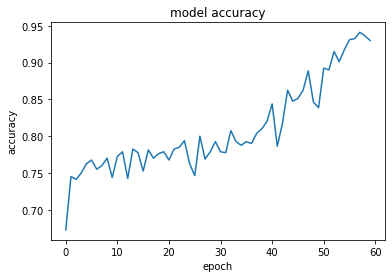

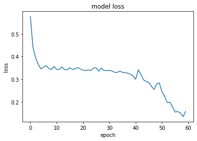

```python
plt.plot(best_history.history['accuracy'])
plt.title('model accuracy')
plt.ylabel('accuracy')
plt.xlabel('epoch')
plt.show()

plt.plot(best_history.history['loss'])
plt.title('model loss')
plt.ylabel('loss')
plt.xlabel('epoch')
plt.show()
```

### Part D: Feature visualization

Because the reference genome is unknown for the given dataset, it was hard to map the transformed data to known DNA motifs. The visualization presented below may not be biologically relevant, but it provided insights into the type of features learned in convulutionary layer and the subsequent LSTM layer.

Feature heatmaps represented the visualization of filters applied to each stage of the model layer. The features were arranged in a horizontal grid for eacy layer. Again, one can conclude from the feature maps that different features are picked up by the convolutionary layer and additional sequencing pattern are learned in LSTM. However, it was challlenging to identify the exact corresponding DNA sequence or motifs highlighted in each section.

```python
######Rerun the best tuned model to achieve trained weights for each of the convolutionary filter weight

model=Sequential()

###CNN
model.add(Conv1D(filters=64, ###tune parameter
                     kernel_size=3, ###open reading frame
                     activation="relu",
                     input_shape=data_new.shape[1:] ) )
model.add(MaxPooling1D(pool_size=3,strides=3)) ##tune parameter
model.add(Dropout(0.2))

###Bidirectional RNN
forward_layer = LSTM(32, ###tune parameter
                         activation='relu',
                         return_sequences=True)
backward_layer = LSTM(32, ###tune parameter
                          activation='relu',
                          return_sequences=True,
                          go_backwards=True)
model.add(Bidirectional(forward_layer,
                            backward_layer=backward_layer))
model.add(Dropout(0.5))

###Flatten
model.add(Flatten())

###Dense
model.add(Dense(64))
model.add(Activation('relu'))

model.add(Dense(1))
model.add(Activation('sigmoid'))

    ##Model compilation
model.compile(loss="binary_crossentropy",
                  optimizer="adam",
                  metrics=['accuracy'])

model.summary()

model.fit(Xtrain, ytrain, epochs=60, batch_size=64)
```

```
Model: "sequential_3"
_________________________________________________________________
Layer (type)                 Output Shape              Param #
=================================================================
conv1d_3 (Conv1D)            (None, 126, 64)           171136
_________________________________________________________________
max_pooling1d_3 (MaxPooling1 (None, 42, 64)            0
_________________________________________________________________
dropout_6 (Dropout)          (None, 42, 64)            0
_________________________________________________________________
bidirectional_3 (Bidirection (None, 42, 64)            24832
_________________________________________________________________
dropout_7 (Dropout)          (None, 42, 64)            0
_________________________________________________________________
flatten_3 (Flatten)          (None, 2688)              0
_________________________________________________________________
dense_6 (Dense)              (None, 64)                172096
_________________________________________________________________
activation_6 (Activation)    (None, 64)                0
_________________________________________________________________
dense_7 (Dense)              (None, 1)                 65
_________________________________________________________________
activation_7 (Activation)    (None, 1)                 0
=================================================================
Total params: 368,129
Trainable params: 368,129
Non-trainable params: 0
_________________________________________________________________
```

```
<tensorflow.python.keras.callbacks.History at 0x2af0abee8a60>
```

#### A. Visualize filters

```python
####Exrtact weights from the first layer - Convolutionary layer
####Normalize filter values to 0-1 so we can visualize them

filters=model.layers[0].get_weights()[0]
f_min, f_max = filters.min(), filters.max()
filters = (filters - f_min) / (f_max - f_min)
```

```python
filters.shape ###three channels, length 891 and 64 filters
```

```
(3, 891, 64)
```

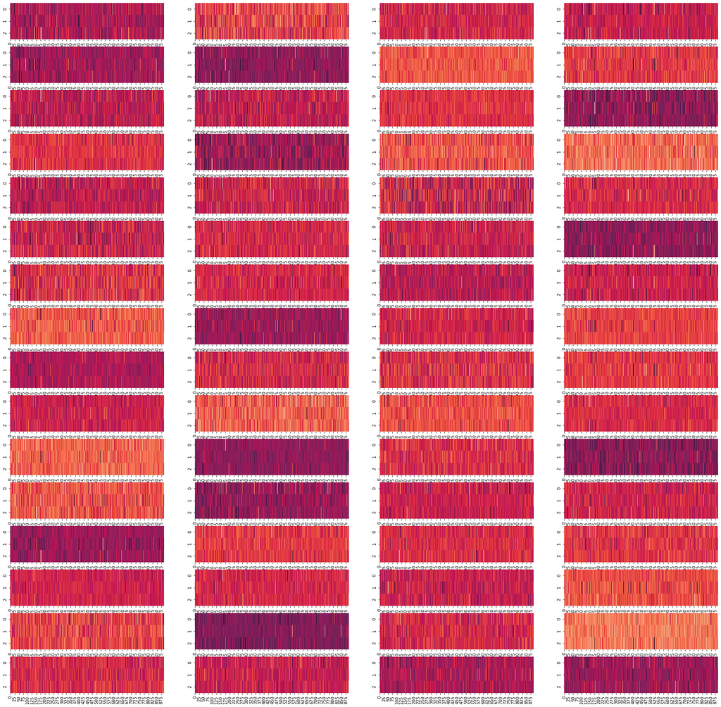

```python
#Plot the features in each filter with all three channels in a graph
plt.figure(figsize=(30,30))
n_filters=64

for i in range(n_filters):
    # get the filter
    plt.subplot(16,4,i+1)
    f = filters[:, :, i]
    sns.heatmap(f,cbar=False)

# show the figure
plt.show()
```

#### B. Visualize feature map

```python
successive_outputs = [layer.output for layer in model.layers[1:]]
visualization_model = tf.keras.models.Model(inputs = model.input, outputs = successive_outputs)

successive_feature_maps = visualization_model.predict(Xtrain)
layer_names = [layer.name for layer in model.layers]
```

```python
successive_feature_maps[0][0,:,1]
```

```
array([0.14713037, 0.        , 0.00171467, 0.        , 0.        ,
       0.09763194, 0.        , 0.        , 0.        , 0.        ,
       0.        , 0.        , 0.        , 0.        , 0.        ,
       0.        , 0.        , 0.22638696, 0.        , 0.        ,
       0.34733197, 0.21098453, 0.46429843, 0.6599321 , 0.48619974,
       0.        , 0.2912924 , 0.16550308, 0.        , 0.        ,
       0.12418623, 0.        , 0.01023728, 0.        , 0.        ,
       0.        , 0.        , 0.        , 0.        , 0.        ,
       0.5338503 , 0.        ], dtype=float32)
```

```
(800, 42, 64)
(800, 42, 64)
(800, 42, 64)
(800, 42, 64)
(800, 2688)
(800, 64)
(800, 64)
(800, 1)
(800, 1)
```

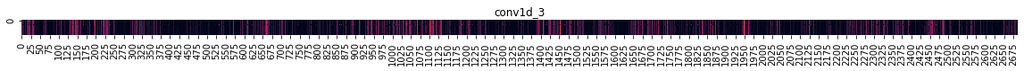

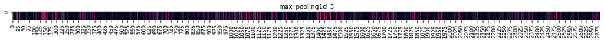

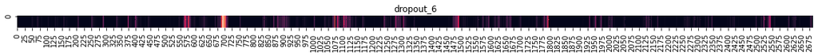

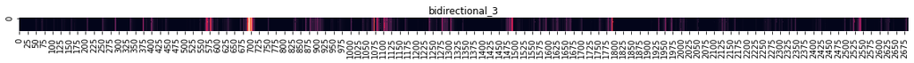

```python
plt.figure(figsize=(30,30))

for layer_name, feature_map in zip(layer_names, successive_feature_maps):
    print(feature_map.shape)
    if len(feature_map.shape) == 3:

    #-------------------------------------------
    # Just do this for the conv / maxpool layers, not the fully-connected layers
    #-------------------------------------------
        n_features = feature_map.shape[-1]  # number of features in the feature map
        size       = feature_map.shape[ 1]  # feature map shape (1, size, size, n_features)

#     # We will tile our images in this matrix
        display_grid = np.zeros((size, size * n_features))

#     #-------------------------------------------------
#     # Postprocess the feature to be visually palatable
#     #-------------------------------------------------
        for i in range(n_features):
            x  = feature_map[0, :, i]
            display_grid[:, i * size : (i + 1) * size] = x # Tile each filter into a horizontal grid

#     #-----------------
#     # Display the grid
#     #-----------------

        scale = 20. / n_features
        plt.figure( figsize=(scale * n_features, scale) )
        plt.title ( layer_name )
        #plt.grid  ( False )
        sns.heatmap(display_grid,cbar=False)
        #plt.imshow( display_grid, aspect='auto', cmap='viridis' )
plt.show()
```

```python
##Save model
model.save("cv5_trained")
```

```
INFO:tensorflow:Assets written to: cv5_trained/assets
```

### Part E: Conclusion and challenges:

A hybrid structure of 1D convolutionary network with bidirectional LSTM structures achieved high performances with a sequential mRNA one-hot-encoded data stacked with neareset information as an input. 1D CNN was chosen due to the 3D nature of the DNA sequencing data. A combination of CNN and RNN allowed the model to learn patterns of the DNA sequences by CNN. A bidirectional RNN further mimics the biological process of translating RNA sequences on a forward and backward strand. This proposed model was able to achieve a testing accuracy of 94% on the downsampled dataset.

Challenges for this project include a biological and a computational aspect:

1. Computational resources: I trained the model on the Harvard Cannon cluster which utilized slurm schedulers. Due to high volumn of requests, I was not able to request high number of CPUs and memories for the task. Thus, this project could be deemed as a pilot run for a subset of the data. It would be more optimal if the random search could include more hyperparameters such as filter sizes for LSTM layers and drop out percentages. It would also be preferable to train on a larger set of data.
2. As mentioned in the feature visualization section, it was challenging to identify underlying biological patterns learned by the filters in the CNN layer and the features learned in subsequent layers. This lack of interpretability can partially be attributed to the stacking structure of the mRNA codes in the data processing step which would require further mapping of the orignal DNA sequences. Another reason can be the lack of reference genome of which these gene sequences are from to allow mapping of known DNA motifs to the features learned at each layer.